# World Bank Indicator Visualizations

Abel Kassa

2/16/2020

## CO2 Emmissons by Country

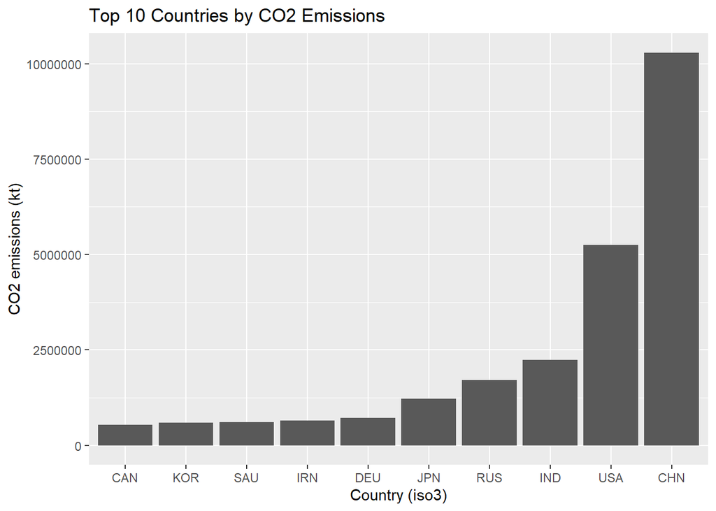

*C02 Emissions by Country:* *What is one notable conclusion or insight you draw from this visualization?*

It’s obvious that China has been emitting more CO2 than all of the countries combined (excluding the USA). I believe this has to do with China’s heavy use of coal as a primary source of energy.

## US Income Equality over Time

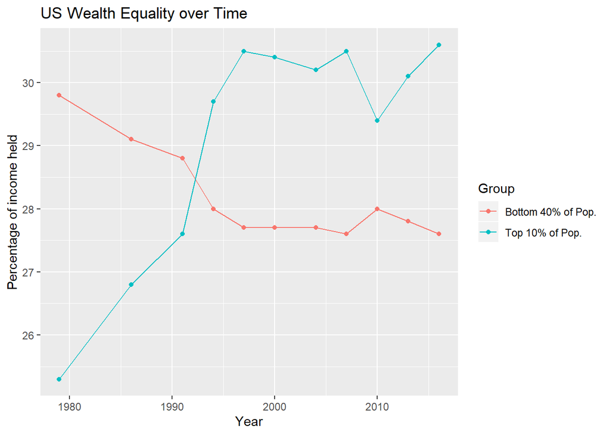

*US Income Equality over Time:* *What is one notable conclusion or insight you draw from this visualization?*

It appears that around the mid 1990’s there was a drastic change in the wealth distribution in the US. The top 10 percent began to gain wealth rapidly around the mid 1990’s and I believe this may have to do with the internet boom around that period.

## Health Expenditures by Country

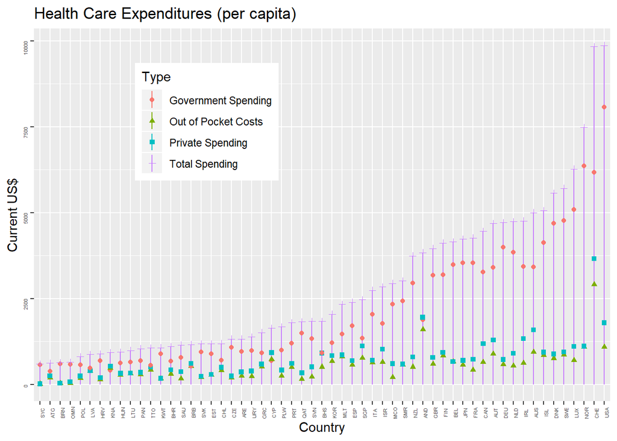

*Health Expenditures by Country: What is one notable conclusion or insight you draw from this visualization?*

The most notable insight I was able to draw was that the USA total spending is dramatically larger than most of the countries on the visualization. The government spending alone shows how much more the USA has to spend on health care expenditures.

## Forestation over Time

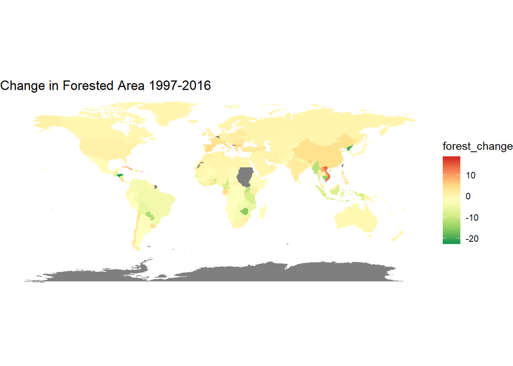

*Changes in Forestation around the World: What is one notable conclusion or insight you draw from this visualization?*

## Growth in Access to Electricity 2000-2015

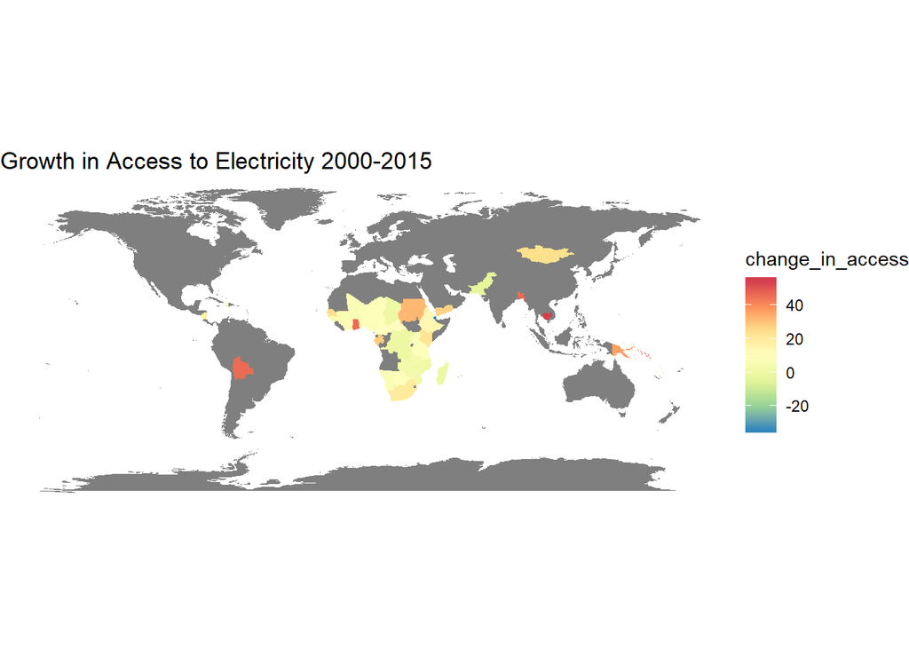

*Growth in Access to Electricity Globally:*

*What question(s) does your visualization attempt to answer?*

My question attempts to answer which region of the world has seen the growth in access to electricity in from 2000-2015. I believe that access to electricity is necessary for a country and its citizens to succeed and this visualization will attempt to answer what region that would be.

*Why did you select this visual layout?*

I chose the map layout as my visualization because I feel that it would show a clear representation of the regions where access to electricity grew and it is easier to understand with a map layout rather than a bar graph or pie chart.

*In what way is this an effective and expressive visualization?*

This an effective and expressive visualization because it is designed to be intuitive and displays the information in a manner that quickly communicates a message to the viewer of the visualization. The visualization is expressive because of the color use and effective due to the map display rather than a line graph.